# GtkNotebook

GtkNotebook — A tabbed notebook container

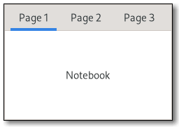

## Functions

| GtkWidget * | gtk_notebook_new () |
| --- | --- |
| GtkNotebookPage * | gtk_notebook_get_page () |
| GListModel * | gtk_notebook_get_pages () |
| GtkWidget * | gtk_notebook_page_get_child () |
| int | gtk_notebook_append_page () |
| int | gtk_notebook_append_page_menu () |
| int | gtk_notebook_prepend_page () |
| int | gtk_notebook_prepend_page_menu () |
| int | gtk_notebook_insert_page () |
| int | gtk_notebook_insert_page_menu () |
| void | gtk_notebook_remove_page () |
| void | gtk_notebook_detach_tab () |
| int | gtk_notebook_page_num () |
| void | gtk_notebook_next_page () |
| void | gtk_notebook_prev_page () |
| void | gtk_notebook_reorder_child () |
| void | gtk_notebook_set_tab_pos () |
| void | gtk_notebook_set_show_tabs () |
| void | gtk_notebook_set_show_border () |
| void | gtk_notebook_set_scrollable () |
| void | gtk_notebook_popup_enable () |
| void | gtk_notebook_popup_disable () |
| int | gtk_notebook_get_current_page () |
| GtkWidget * | gtk_notebook_get_menu_label () |
| GtkWidget * | gtk_notebook_get_nth_page () |
| int | gtk_notebook_get_n_pages () |
| GtkWidget * | gtk_notebook_get_tab_label () |
| void | gtk_notebook_set_menu_label () |
| void | gtk_notebook_set_menu_label_text () |
| void | gtk_notebook_set_tab_label () |
| void | gtk_notebook_set_tab_label_text () |
| void | gtk_notebook_set_tab_reorderable () |
| void | gtk_notebook_set_tab_detachable () |
| const char * | gtk_notebook_get_menu_label_text () |
| gboolean | gtk_notebook_get_scrollable () |
| gboolean | gtk_notebook_get_show_border () |
| gboolean | gtk_notebook_get_show_tabs () |
| const char * | gtk_notebook_get_tab_label_text () |
| GtkPositionType | gtk_notebook_get_tab_pos () |
| gboolean | gtk_notebook_get_tab_reorderable () |
| gboolean | gtk_notebook_get_tab_detachable () |
| void | gtk_notebook_set_current_page () |
| void | gtk_notebook_set_group_name () |
| const char * | gtk_notebook_get_group_name () |
| void | gtk_notebook_set_action_widget () |
| GtkWidget * | gtk_notebook_get_action_widget () |

## Properties

| gboolean | enable-popup | Read / Write |
| --- | --- | --- |
| char * | group-name | Read / Write |
| int | page | Read / Write |
| GListModel * | pages | Read |
| gboolean | scrollable | Read / Write |
| gboolean | show-border | Read / Write |
| gboolean | show-tabs | Read / Write |
| GtkPositionType | tab-pos | Read / Write |
| GtkWidget * | child | Read / Write / Construct Only |
| gboolean | detachable | Read / Write |
| GtkWidget * | menu | Read / Write / Construct Only |
| char * | menu-label | Read / Write |
| int | position | Read / Write |
| gboolean | reorderable | Read / Write |
| GtkWidget * | tab | Read / Write / Construct Only |
| gboolean | tab-expand | Read / Write |
| gboolean | tab-fill | Read / Write |
| char * | tab-label | Read / Write |

## Signals

| gboolean | change-current-page | Action |
| --- | --- | --- |
| GtkNotebook* | create-window | Run Last |
| gboolean | focus-tab | Action |
| void | move-focus-out | Action |
| void | page-added | Run Last |
| void | page-removed | Run Last |
| void | page-reordered | Run Last |
| gboolean | reorder-tab | Action |
| gboolean | select-page | Action |
| void | switch-page | Run Last |

## Actions

|  | menu.popup |  |
| --- | --- | --- |

## Types and Values

|  | GtkNotebook |
| --- | --- |
|  | GtkNotebookPage |
| enum | GtkNotebookTab |

## Object Hierarchy

```
    GObject
    ├── GInitiallyUnowned
    │   ╰── GtkWidget
    │       ╰── GtkNotebook
    ╰── GtkNotebookPage
```

## Implemented Interfaces

GtkNotebook implements GtkAccessible, GtkBuildable and GtkConstraintTarget.

## Includes

```
#include <gtk/gtk.h>
```

## Description

The GtkNotebook widget is a layout container whose children are pages that can be switched between using tab labels along one edge.

There are many configuration options for GtkNotebook. Among other things, you can choose on which edge the tabs appear (see `gtk_notebook_set_tab_pos()`), whether, if there are too many tabs to fit the notebook should be made bigger or scrolling arrows added (see `gtk_notebook_set_scrollable()`), and whether there will be a popup menu allowing the users to switch pages. (see `gtk_notebook_popup_enable()`, `gtk_notebook_popup_disable()`)

### GtkNotebook as GtkBuildable

The GtkNotebook implementation of the GtkBuildable interface supports placing children into tabs by specifying “tab” as the “type” attribute of a <child> element. Note that the content of the tab must be created before the tab can be filled. A tab child can be specified without specifying a <child> type attribute.

To add a child widget in the notebooks action area, specify "action-start" or “action-end” as the “type” attribute of the <child> element.

### CSS nodes

GtkNotebook has a main CSS node with name `notebook`, a subnode with name `header` and below that a subnode with name `tabs` which contains one subnode per tab with name `tab`.

If action widgets are present, their CSS nodes are placed next to the `tabs` node. If the notebook is scrollable, CSS nodes with name `arrow` are placed as first and last child of the `tabs` node.

The main node gets the `.frame` style class when the notebook has a border (see `gtk_notebook_set_show_border()`).

The header node gets one of the style class `.top`, `.bottom`, `.left` or `.right`, depending on where the tabs are placed. For reorderable pages, the tab node gets the `.reorderable-page` class.

A `tab` node gets the `.dnd` style class while it is moved with drag-and-drop.

The nodes are always arranged from left-to-right, regardless of text direction.

### Accessibility

GtkNotebook uses the following roles:

- `GTK_ACCESSIBLE_ROLE_GROUP` for the notebook widget
- `GTK_ACCESSIBLE_ROLE_TAB_LIST` for the list of tabs
- `GTK_ACCESSIBLE_ROLE_TAB` role for each tab
- `GTK_ACCESSIBLE_ROLE_TAB_PANEL` for each page

## Functions

### gtk_notebook_new ()

```
GtkWidget *
gtk_notebook_new (void);
```

Creates a new GtkNotebook widget with no pages.

#### Returns

the newly created GtkNotebook

### gtk_notebook_get_page ()

```
GtkNotebookPage *
gtk_notebook_get_page (GtkNotebook *notebook,
                       GtkWidget *child);
```

Returns the GtkNotebookPage for *`child`* .

#### Parameters

| notebook | a GtkNotebook |  |
| --- | --- | --- |
| child | a child of *`notebook`* |  |

#### Returns

the GtkNotebookPage for *`child`* .

[transfer none]

### gtk_notebook_get_pages ()

```
GListModel *
gtk_notebook_get_pages (GtkNotebook *notebook);
```

Returns a GListModel that contains the pages of the notebook, and can be used to keep an up-to-date view.

#### Parameters

| notebook | a GtkNotebook |  |
| --- | --- | --- |

#### Returns

a GListModel for the notebook's children.

[transfer full][attributes element-type=GtkNotebookPage]

### gtk_notebook_page_get_child ()

```
GtkWidget *
gtk_notebook_page_get_child (GtkNotebookPage *page);
```

Returns the notebook child to which *`page`* belongs.

#### Parameters

| page | a GtkNotebookPage |  |
| --- | --- | --- |

#### Returns

the child to which *`page`* belongs.

[transfer none]

### gtk_notebook_append_page ()

```
int
gtk_notebook_append_page (GtkNotebook *notebook,
                          GtkWidget *child,
                          GtkWidget *tab_label);
```

Appends a page to *`notebook`* .

#### Parameters

| notebook | a GtkNotebook |  |
| --- | --- | --- |
| child | the GtkWidget to use as the contents of the page |  |
| tab_label | the GtkWidget to be used as the label for the page, or `NULL` to use the default label, “page N”. | [allow-none] |

#### Returns

the index (starting from 0) of the appended page in the notebook, or -1 if function fails

### gtk_notebook_append_page_menu ()

```
int
gtk_notebook_append_page_menu (GtkNotebook *notebook,
                               GtkWidget *child,
                               GtkWidget *tab_label,
                               GtkWidget *menu_label);
```

Appends a page to *`notebook`* , specifying the widget to use as the label in the popup menu.

#### Parameters

| notebook | a GtkNotebook |  |
| --- | --- | --- |
| child | the GtkWidget to use as the contents of the page |  |
| tab_label | the GtkWidget to be used as the label for the page, or `NULL` to use the default label, “page N”. | [allow-none] |
| menu_label | the widget to use as a label for the page-switch menu, if that is enabled. If `NULL`, and *`tab_label`* is a GtkLabel or `NULL`, then the menu label will be a newly created label with the same text as… | [allow-none] |

#### Returns

the index (starting from 0) of the appended page in the notebook, or -1 if function fails

### gtk_notebook_prepend_page ()

```
int
gtk_notebook_prepend_page (GtkNotebook *notebook,
                           GtkWidget *child,
                           GtkWidget *tab_label);
```

Prepends a page to *`notebook`* .

#### Parameters

| notebook | a GtkNotebook |  |
| --- | --- | --- |
| child | the GtkWidget to use as the contents of the page |  |
| tab_label | the GtkWidget to be used as the label for the page, or `NULL` to use the default label, “page N”. | [allow-none] |

#### Returns

the index (starting from 0) of the prepended page in the notebook, or -1 if function fails

### gtk_notebook_prepend_page_menu ()

```
int
gtk_notebook_prepend_page_menu (GtkNotebook *notebook,
                                GtkWidget *child,
                                GtkWidget *tab_label,
                                GtkWidget *menu_label);
```

Prepends a page to *`notebook`* , specifying the widget to use as the label in the popup menu.

#### Parameters

| notebook | a GtkNotebook |  |
| --- | --- | --- |
| child | the GtkWidget to use as the contents of the page |  |
| tab_label | the GtkWidget to be used as the label for the page, or `NULL` to use the default label, “page N”. | [allow-none] |
| menu_label | the widget to use as a label for the page-switch menu, if that is enabled. If `NULL`, and *`tab_label`* is a GtkLabel or `NULL`, then the menu label will be a newly created label with the same text as… | [allow-none] |

#### Returns

the index (starting from 0) of the prepended page in the notebook, or -1 if function fails

### gtk_notebook_insert_page ()

```
int
gtk_notebook_insert_page (GtkNotebook *notebook,
                          GtkWidget *child,
                          GtkWidget *tab_label,
                          int position);
```

Insert a page into *`notebook`* at the given position.

#### Parameters

| notebook | a GtkNotebook |  |
| --- | --- | --- |
| child | the GtkWidget to use as the contents of the page |  |
| tab_label | the GtkWidget to be used as the label for the page, or `NULL` to use the default label, “page N”. | [allow-none] |
| position | the index (starting at 0) at which to insert the page, or -1 to append the page after all other pages |  |

#### Returns

the index (starting from 0) of the inserted page in the notebook, or -1 if function fails

### gtk_notebook_insert_page_menu ()

```
int
gtk_notebook_insert_page_menu (GtkNotebook *notebook,
                               GtkWidget *child,
                               GtkWidget *tab_label,
                               GtkWidget *menu_label,
                               int position);
```

Insert a page into *`notebook`* at the given position, specifying the widget to use as the label in the popup menu.

#### Parameters

| notebook | a GtkNotebook |  |
| --- | --- | --- |
| child | the GtkWidget to use as the contents of the page |  |
| tab_label | the GtkWidget to be used as the label for the page, or `NULL` to use the default label, “page N”. | [allow-none] |
| menu_label | the widget to use as a label for the page-switch menu, if that is enabled. If `NULL`, and *`tab_label`* is a GtkLabel or `NULL`, then the menu label will be a newly created label with the same text as… | [allow-none] |
| position | the index (starting at 0) at which to insert the page, or -1 to append the page after all other pages. |  |

#### Returns

the index (starting from 0) of the inserted page in the notebook

### gtk_notebook_remove_page ()

```
void
gtk_notebook_remove_page (GtkNotebook *notebook,
                          int page_num);
```

Removes a page from the notebook given its index in the notebook.

#### Parameters

| notebook | a GtkNotebook |  |
| --- | --- | --- |
| page_num | the index of a notebook page, starting from 0. If -1, the last page will be removed. |  |

### gtk_notebook_detach_tab ()

```
void
gtk_notebook_detach_tab (GtkNotebook *notebook,
                         GtkWidget *child);
```

Removes the child from the notebook.

This function is very similar to `gtk_notebook_remove_page()`, but additionally informs the notebook that the removal is happening as part of a tab DND operation, which should not be cancelled.

#### Parameters

| notebook | a GtkNotebook |  |
| --- | --- | --- |
| child | a child |  |

### gtk_notebook_page_num ()

```
int
gtk_notebook_page_num (GtkNotebook *notebook,
                       GtkWidget *child);
```

Finds the index of the page which contains the given child widget.

#### Parameters

| notebook | a GtkNotebook |  |
| --- | --- | --- |
| child | a GtkWidget |  |

#### Returns

the index of the page containing *`child`* , or -1 if *`child`* is not in the notebook

### gtk_notebook_next_page ()

```
void
gtk_notebook_next_page (GtkNotebook *notebook);
```

Switches to the next page. Nothing happens if the current page is the last page.

#### Parameters

| notebook | a GtkNotebook |  |
| --- | --- | --- |

### gtk_notebook_prev_page ()

```
void
gtk_notebook_prev_page (GtkNotebook *notebook);
```

Switches to the previous page. Nothing happens if the current page is the first page.

#### Parameters

| notebook | a GtkNotebook |  |
| --- | --- | --- |

### gtk_notebook_reorder_child ()

```
void
gtk_notebook_reorder_child (GtkNotebook *notebook,
                            GtkWidget *child,
                            int position);
```

Reorders the page containing *`child`* , so that it appears in position *`position`* . If *`position`* is greater than or equal to the number of children in the list or negative, *`child`* will be moved to the end of the list.

#### Parameters

| notebook | a GtkNotebook |  |
| --- | --- | --- |
| child | the child to move |  |
| position | the new position, or -1 to move to the end |  |

### gtk_notebook_set_tab_pos ()

```
void
gtk_notebook_set_tab_pos (GtkNotebook *notebook,
                          GtkPositionType pos);
```

Sets the edge at which the tabs for switching pages in the notebook are drawn.

#### Parameters

| notebook | a GtkNotebook. |  |
| --- | --- | --- |
| pos | the edge to draw the tabs at |  |

### gtk_notebook_set_show_tabs ()

```
void
gtk_notebook_set_show_tabs (GtkNotebook *notebook,
                            gboolean show_tabs);
```

Sets whether to show the tabs for the notebook or not.

#### Parameters

| notebook | a GtkNotebook |  |
| --- | --- | --- |
| show_tabs | `TRUE` if the tabs should be shown |  |

### gtk_notebook_set_show_border ()

```
void
gtk_notebook_set_show_border (GtkNotebook *notebook,
                              gboolean show_border);
```

Sets whether a bevel will be drawn around the notebook pages. This only has a visual effect when the tabs are not shown. See `gtk_notebook_set_show_tabs()`.

#### Parameters

| notebook | a GtkNotebook |  |
| --- | --- | --- |
| show_border | `TRUE` if a bevel should be drawn around the notebook |  |

### gtk_notebook_set_scrollable ()

```
void
gtk_notebook_set_scrollable (GtkNotebook *notebook,
                             gboolean scrollable);
```

Sets whether the tab label area will have arrows for scrolling if there are too many tabs to fit in the area.

#### Parameters

| notebook | a GtkNotebook |  |
| --- | --- | --- |
| scrollable | `TRUE` if scroll arrows should be added |  |

### gtk_notebook_popup_enable ()

```
void
gtk_notebook_popup_enable (GtkNotebook *notebook);
```

Enables the popup menu: if the user clicks with the right mouse button on the tab labels, a menu with all the pages will be popped up.

#### Parameters

| notebook | a GtkNotebook |  |
| --- | --- | --- |

### gtk_notebook_popup_disable ()

```
void
gtk_notebook_popup_disable (GtkNotebook *notebook);
```

Disables the popup menu.

#### Parameters

| notebook | a GtkNotebook |  |
| --- | --- | --- |

### gtk_notebook_get_current_page ()

```
int
gtk_notebook_get_current_page (GtkNotebook *notebook);
```

Returns the page number of the current page.

#### Parameters

| notebook | a GtkNotebook |  |
| --- | --- | --- |

#### Returns

the index (starting from 0) of the current page in the notebook. If the notebook has no pages, then -1 will be returned.

### gtk_notebook_get_menu_label ()

```
GtkWidget *
gtk_notebook_get_menu_label (GtkNotebook *notebook,
                             GtkWidget *child);
```

Retrieves the menu label widget of the page containing *`child`* .

#### Parameters

| notebook | a GtkNotebook |  |
| --- | --- | --- |
| child | a widget contained in a page of *`notebook`* |  |

#### Returns

the menu label, or `NULL` if the notebook page does not have a menu label other than the default (the tab label).

[nullable][transfer none]

### gtk_notebook_get_nth_page ()

```
GtkWidget *
gtk_notebook_get_nth_page (GtkNotebook *notebook,
                           int page_num);
```

Returns the child widget contained in page number *`page_num`* .

#### Parameters

| notebook | a GtkNotebook |  |
| --- | --- | --- |
| page_num | the index of a page in the notebook, or -1 to get the last page |  |

#### Returns

the child widget, or `NULL` if *`page_num`* is out of bounds.

[nullable][transfer none]

### gtk_notebook_get_n_pages ()

```
int
gtk_notebook_get_n_pages (GtkNotebook *notebook);
```

Gets the number of pages in a notebook.

#### Parameters

| notebook | a GtkNotebook |  |
| --- | --- | --- |

#### Returns

the number of pages in the notebook

### gtk_notebook_get_tab_label ()

```
GtkWidget *
gtk_notebook_get_tab_label (GtkNotebook *notebook,
                            GtkWidget *child);
```

Returns the tab label widget for the page *`child`* . `NULL` is returned if *`child`* is not in *`notebook`* or if no tab label has specifically been set for *`child`* .

#### Parameters

| notebook | a GtkNotebook |  |
| --- | --- | --- |
| child | the page |  |

#### Returns

the tab label.

[transfer none][nullable]

### gtk_notebook_set_menu_label ()

```
void
gtk_notebook_set_menu_label (GtkNotebook *notebook,
                             GtkWidget *child,
                             GtkWidget *menu_label);
```

Changes the menu label for the page containing *`child`* .

#### Parameters

| notebook | a GtkNotebook |  |
| --- | --- | --- |
| child | the child widget |  |
| menu_label | the menu label, or `NULL` for default. | [allow-none] |

### gtk_notebook_set_menu_label_text ()

```
void
gtk_notebook_set_menu_label_text (GtkNotebook *notebook,
                                  GtkWidget *child,
                                  const char *menu_text);
```

Creates a new label and sets it as the menu label of *`child`* .

#### Parameters

| notebook | a GtkNotebook |  |
| --- | --- | --- |
| child | the child widget |  |
| menu_text | the label text |  |

### gtk_notebook_set_tab_label ()

```
void
gtk_notebook_set_tab_label (GtkNotebook *notebook,
                            GtkWidget *child,
                            GtkWidget *tab_label);
```

Changes the tab label for *`child`* . If `NULL` is specified for *`tab_label`* , then the page will have the label “page N”.

#### Parameters

| notebook | a GtkNotebook |  |
| --- | --- | --- |
| child | the page |  |
| tab_label | the tab label widget to use, or `NULL` for default tab label. | [allow-none] |

### gtk_notebook_set_tab_label_text ()

```
void
gtk_notebook_set_tab_label_text (GtkNotebook *notebook,
                                 GtkWidget *child,
                                 const char *tab_text);
```

Creates a new label and sets it as the tab label for the page containing *`child`* .

#### Parameters

| notebook | a GtkNotebook |  |
| --- | --- | --- |
| child | the page |  |
| tab_text | the label text |  |

### gtk_notebook_set_tab_reorderable ()

```
void
gtk_notebook_set_tab_reorderable (GtkNotebook *notebook,
                                  GtkWidget *child,
                                  gboolean reorderable);
```

Sets whether the notebook tab can be reordered via drag and drop or not.

#### Parameters

| notebook | a GtkNotebook |  |
| --- | --- | --- |
| child | a child GtkWidget |  |
| reorderable | whether the tab is reorderable or not |  |

### gtk_notebook_set_tab_detachable ()

```
void
gtk_notebook_set_tab_detachable (GtkNotebook *notebook,
                                 GtkWidget *child,
                                 gboolean detachable);
```

Sets whether the tab can be detached from *`notebook`* to another notebook or widget.

Note that 2 notebooks must share a common group identificator (see `gtk_notebook_set_group_name()`) to allow automatic tabs interchange between them.

If you want a widget to interact with a notebook through DnD (i.e.: accept dragged tabs from it) it must be set as a drop destination and accept the target “GTK_NOTEBOOK_TAB”. The notebook will fill the selection with a GtkWidget** pointing to the child widget that corresponds to the dropped tab.

Note that you should use `gtk_notebook_detach_tab()` instead of `gtk_notebook_remove_page()` if you want to remove the tab from the source notebook as part of accepting a drop. Otherwise, the source notebook will think that the dragged tab was removed from underneath the ongoing drag operation, and will initiate a drag cancel animation.

[output not shown]

If you want a notebook to accept drags from other widgets, you will have to set your own DnD code to do it.

#### Parameters

| notebook | a GtkNotebook |  |
| --- | --- | --- |
| child | a child GtkWidget |  |
| detachable | whether the tab is detachable or not |  |

### gtk_notebook_get_menu_label_text ()

```
const char *
gtk_notebook_get_menu_label_text (GtkNotebook *notebook,
                                  GtkWidget *child);
```

Retrieves the text of the menu label for the page containing *`child`* .

#### Parameters

| notebook | a GtkNotebook |  |
| --- | --- | --- |
| child | the child widget of a page of the notebook. |  |

#### Returns

the text of the tab label, or `NULL` if the widget does not have a menu label other than the default menu label, or the menu label widget is not a GtkLabel. The string is owned by the widget and must not be freed.

[nullable]

### gtk_notebook_get_scrollable ()

```
gboolean
gtk_notebook_get_scrollable (GtkNotebook *notebook);
```

Returns whether the tab label area has arrows for scrolling. See `gtk_notebook_set_scrollable()`.

#### Parameters

| notebook | a GtkNotebook |  |
| --- | --- | --- |

#### Returns

`TRUE` if arrows for scrolling are present

### gtk_notebook_get_show_border ()

```
gboolean
gtk_notebook_get_show_border (GtkNotebook *notebook);
```

Returns whether a bevel will be drawn around the notebook pages. See `gtk_notebook_set_show_border()`.

#### Parameters

| notebook | a GtkNotebook |  |
| --- | --- | --- |

#### Returns

`TRUE` if the bevel is drawn

### gtk_notebook_get_show_tabs ()

```
gboolean
gtk_notebook_get_show_tabs (GtkNotebook *notebook);
```

Returns whether the tabs of the notebook are shown. See `gtk_notebook_set_show_tabs()`.

#### Parameters

| notebook | a GtkNotebook |  |
| --- | --- | --- |

#### Returns

`TRUE` if the tabs are shown

### gtk_notebook_get_tab_label_text ()

```
const char *
gtk_notebook_get_tab_label_text (GtkNotebook *notebook,
                                 GtkWidget *child);
```

Retrieves the text of the tab label for the page containing *`child`* .

#### Parameters

| notebook | a GtkNotebook |  |
| --- | --- | --- |
| child | a widget contained in a page of *`notebook`* |  |

#### Returns

the text of the tab label, or `NULL` if the tab label widget is not a GtkLabel. The string is owned by the widget and must not be freed.

[nullable]

### gtk_notebook_get_tab_pos ()

```
GtkPositionType
gtk_notebook_get_tab_pos (GtkNotebook *notebook);
```

Gets the edge at which the tabs for switching pages in the notebook are drawn.

#### Parameters

| notebook | a GtkNotebook |  |
| --- | --- | --- |

#### Returns

the edge at which the tabs are drawn

### gtk_notebook_get_tab_reorderable ()

```
gboolean
gtk_notebook_get_tab_reorderable (GtkNotebook *notebook,
                                  GtkWidget *child);
```

Gets whether the tab can be reordered via drag and drop or not.

#### Parameters

| notebook | a GtkNotebook |  |
| --- | --- | --- |
| child | a child GtkWidget |  |

#### Returns

`TRUE` if the tab is reorderable.

### gtk_notebook_get_tab_detachable ()

```
gboolean
gtk_notebook_get_tab_detachable (GtkNotebook *notebook,
                                 GtkWidget *child);
```

Returns whether the tab contents can be detached from *`notebook`* .

#### Parameters

| notebook | a GtkNotebook |  |
| --- | --- | --- |
| child | a child GtkWidget |  |

#### Returns

`TRUE` if the tab is detachable.

### gtk_notebook_set_current_page ()

```
void
gtk_notebook_set_current_page (GtkNotebook *notebook,
                               int page_num);
```

Switches to the page number *`page_num`* .

Note that due to historical reasons, GtkNotebook refuses to switch to a page unless the child widget is visible. Therefore, it is recommended to show child widgets before adding them to a notebook.

#### Parameters

| notebook | a GtkNotebook |  |
| --- | --- | --- |
| page_num | index of the page to switch to, starting from 0. If negative, the last page will be used. If greater than the number of pages in the notebook, nothing will be done. |  |

### gtk_notebook_set_group_name ()

```
void
gtk_notebook_set_group_name (GtkNotebook *notebook,
                             const char *group_name);
```

Sets a group name for *`notebook`* .

Notebooks with the same name will be able to exchange tabs via drag and drop. A notebook with a `NULL` group name will not be able to exchange tabs with any other notebook.

#### Parameters

| notebook | a GtkNotebook |  |
| --- | --- | --- |
| group_name | the name of the notebook group, or `NULL` to unset it. | [allow-none] |

### gtk_notebook_get_group_name ()

```
const char *
gtk_notebook_get_group_name (GtkNotebook *notebook);
```

Gets the current group name for *`notebook`* .

#### Parameters

| notebook | a GtkNotebook |  |
| --- | --- | --- |

#### Returns

the group name, or `NULL` if none is set.

[nullable][transfer none]

### gtk_notebook_set_action_widget ()

```
void
gtk_notebook_set_action_widget (GtkNotebook *notebook,
                                GtkWidget *widget,
                                GtkPackType pack_type);
```

Sets *`widget`* as one of the action widgets. Depending on the pack type the widget will be placed before or after the tabs. You can use a GtkBox if you need to pack more than one widget on the same side.

#### Parameters

| notebook | a GtkNotebook |  |
| --- | --- | --- |
| widget | a GtkWidget |  |
| pack_type | pack type of the action widget |  |

### gtk_notebook_get_action_widget ()

```
GtkWidget *
gtk_notebook_get_action_widget (GtkNotebook *notebook,
                                GtkPackType pack_type);
```

Gets one of the action widgets. See `gtk_notebook_set_action_widget()`.

#### Parameters

| notebook | a GtkNotebook |  |
| --- | --- | --- |
| pack_type | pack type of the action widget to receive |  |

#### Returns

The action widget with the given *`pack_type`* or `NULL` when this action widget has not been set.

[nullable][transfer none]

## Types and Values

### GtkNotebook

```
typedef struct _GtkNotebook GtkNotebook;
```

### GtkNotebookPage

```
typedef struct _GtkNotebookPage GtkNotebookPage;
```

A page in the GtkNotebook.

The `GtkNotebookPage` structure only contains private data.

### enum GtkNotebookTab

The parameter used in the action signals of GtkNotebook.

#### Members

| GTK_NOTEBOOK_TAB_FIRST | the first tab in the notebook |  |
| --- | --- | --- |
| GTK_NOTEBOOK_TAB_LAST | the last tab in the notebook |  |

## Property Details

### The `“enable-popup”` property

```
  “enable-popup”             gboolean
```

If TRUE, pressing the right mouse button on the notebook pops up a menu that you can use to go to a page.

Owner: GtkNotebook

Flags: Read / Write

Default value: FALSE

### The `“group-name”` property

```
  “group-name”               char *
```

Group name for tab drag and drop.

Owner: GtkNotebook

Flags: Read / Write

Default value: NULL

### The `“page”` property

```
  “page”                     int
```

The index of the current page.

Owner: GtkNotebook

Flags: Read / Write

Allowed values: >= -1

Default value: -1

### The `“pages”` property

```
  “pages”                    GListModel *
```

The pages of the notebook.

Owner: GtkNotebook

Flags: Read

### The `“scrollable”` property

```
  “scrollable”               gboolean
```

If TRUE, scroll arrows are added if there are too many tabs to fit.

Owner: GtkNotebook

Flags: Read / Write

Default value: FALSE

### The `“show-border”` property

```
  “show-border”              gboolean
```

Whether the border should be shown.

Owner: GtkNotebook

Flags: Read / Write

Default value: TRUE

### The `“show-tabs”` property

```
  “show-tabs”                gboolean
```

Whether tabs should be shown.

Owner: GtkNotebook

Flags: Read / Write

Default value: TRUE

### The `“tab-pos”` property

```
  “tab-pos”                  GtkPositionType
```

Which side of the notebook holds the tabs.

Owner: GtkNotebook

Flags: Read / Write

Default value: GTK_POS_TOP

### The `“child”` property

```
  “child”                    GtkWidget *
```

The child for this page.

Owner: GtkNotebookPage

Flags: Read / Write / Construct Only

### The `“detachable”` property

```
  “detachable”               gboolean
```

Whether the tab is detachable.

Owner: GtkNotebookPage

Flags: Read / Write

Default value: FALSE

### The `“menu”` property

```
  “menu”                     GtkWidget *
```

The label widget displayed in the child’s menu entry.

Owner: GtkNotebookPage

Flags: Read / Write / Construct Only

### The `“menu-label”` property

```
  “menu-label”               char *
```

The text of the menu widget.

Owner: GtkNotebookPage

Flags: Read / Write

Default value: NULL

### The `“position”` property

```
  “position”                 int
```

The index of the child in the parent.

Owner: GtkNotebookPage

Flags: Read / Write

Allowed values: >= -1

Default value: 0

### The `“reorderable”` property

```
  “reorderable”              gboolean
```

Whether the tab is reorderable by user action.

Owner: GtkNotebookPage

Flags: Read / Write

Default value: FALSE

### The `“tab”` property

```
  “tab”                      GtkWidget *
```

The tab widget for this page.

Owner: GtkNotebookPage

Flags: Read / Write / Construct Only

### The `“tab-expand”` property

```
  “tab-expand”               gboolean
```

Whether to expand the child’s tab.

Owner: GtkNotebookPage

Flags: Read / Write

Default value: FALSE

### The `“tab-fill”` property

```
  “tab-fill”                 gboolean
```

Whether the child’s tab should fill the allocated area.

Owner: GtkNotebookPage

Flags: Read / Write

Default value: TRUE

### The `“tab-label”` property

```
  “tab-label”                char *
```

The text of the tab widget.

Owner: GtkNotebookPage

Flags: Read / Write

Default value: NULL

## Signal Details

### The `“change-current-page”` signal

```
gboolean
user_function (GtkNotebook *notebook,
               int          arg1,
               gpointer     user_data)
```

Flags: Action

### The `“create-window”` signal

```
GtkNotebook*
user_function (GtkNotebook *notebook,
               GtkWidget   *page,
               gpointer     user_data)
```

The ::create-window signal is emitted when a detachable tab is dropped on the root window.

A handler for this signal can create a window containing a notebook where the tab will be attached. It is also responsible for moving/resizing the window and adding the necessary properties to the notebook (e.g. the “group-name” ).

#### Parameters

| notebook | the GtkNotebook emitting the signal |  |
| --- | --- | --- |
| page | the tab of *`notebook`* that is being detached |  |
| user_data | user data set when the signal handler was connected. |  |

#### Returns

a GtkNotebook that *`page`* should be added to, or `NULL`.

[transfer none]

Flags: Run Last

### The `“focus-tab”` signal

```
gboolean
user_function (GtkNotebook   *notebook,
               GtkNotebookTab arg1,
               gpointer       user_data)
```

Flags: Action

### The `“move-focus-out”` signal

```
void
user_function (GtkNotebook     *notebook,
               GtkDirectionType arg1,
               gpointer         user_data)
```

Flags: Action

### The `“page-added”` signal

```
void
user_function (GtkNotebook *notebook,
               GtkWidget   *child,
               guint        page_num,
               gpointer     user_data)
```

the ::page-added signal is emitted in the notebook right after a page is added to the notebook.

#### Parameters

| notebook | the GtkNotebook |  |
| --- | --- | --- |
| child | the child GtkWidget affected |  |
| page_num | the new page number for *`child`* |  |
| user_data | user data set when the signal handler was connected. |  |

Flags: Run Last

### The `“page-removed”` signal

```
void
user_function (GtkNotebook *notebook,
               GtkWidget   *child,
               guint        page_num,
               gpointer     user_data)
```

the ::page-removed signal is emitted in the notebook right after a page is removed from the notebook.

#### Parameters

| notebook | the GtkNotebook |  |
| --- | --- | --- |
| child | the child GtkWidget affected |  |
| page_num | the *`child`* page number |  |
| user_data | user data set when the signal handler was connected. |  |

Flags: Run Last

### The `“page-reordered”` signal

```
void
user_function (GtkNotebook *notebook,
               GtkWidget   *child,
               guint        page_num,
               gpointer     user_data)
```

the ::page-reordered signal is emitted in the notebook right after a page has been reordered.

#### Parameters

| notebook | the GtkNotebook |  |
| --- | --- | --- |
| child | the child GtkWidget affected |  |
| page_num | the new page number for *`child`* |  |
| user_data | user data set when the signal handler was connected. |  |

Flags: Run Last

### The `“reorder-tab”` signal

```
gboolean
user_function (GtkNotebook     *notebook,
               GtkDirectionType arg1,
               gboolean         arg2,
               gpointer         user_data)
```

Flags: Action

### The `“select-page”` signal

```
gboolean
user_function (GtkNotebook *notebook,
               gboolean     arg1,
               gpointer     user_data)
```

Flags: Action

### The `“switch-page”` signal

```
void
user_function (GtkNotebook *notebook,
               GtkWidget   *page,
               guint        page_num,
               gpointer     user_data)
```

Emitted when the user or a function changes the current page.

#### Parameters

| notebook | the object which received the signal. |  |
| --- | --- | --- |
| page | the new current page |  |
| page_num | the index of the page |  |
| user_data | user data set when the signal handler was connected. |  |

Flags: Run Last

## Action Details

### The `“menu.popup”` action

Opens the context menu.